# Praca Domowa 1

Agata Makarewicz

23 03 2021

### Wstęp

Naszym zadaniem będzie analiza wyjaśniająca decyzję modelu uczenia maszynowego (w jaki sposób poszczególne zmienne na nią wpływają). Będą to wyjaśnienia lokalne, dla pojedynczych predykcji.

Skorzystamy ze zbioru danych `phones` zawierającego informacje o cechach różnych telefonów dostępnych na rynku. Rozważamy problem regresji (chcemy przewidzieć zmienną `price`) przy wykorzystaniu lasu losowego zaimplementowany w pakiecie `ranger`. Analizy dokonamy na poniższych obserwacjach:

|  | name | brand | back_camera_mpix | front_camera_mpix | battery_mAh | ram_gb | flash_gb | diag | height_px | width_px | price |
| --- | --- | --- | --- | --- | --- | --- | --- | --- | --- | --- | --- |
| 1 | Xiaomi Mi 10T 6+128GB | Xiaomi | 64 | 20 | 5000 | 6 | 128 | 6.67 | 2400 | 1080 | 1999 |
| 4 | Xiaomi Redmi 9 4+64 | Xiaomi | 13 | 8 | 5020 | 4 | 64 | 6.53 | 2340 | 1080 | 619 |
| 26 | Samsung Galaxy Z Fold2 5G | Samsung | 12 | 10 | 4500 | 12 | 256 | 7.60 | 2208 | 1768 | 8799 |
| 120 | Huawei Y7 2019 | Huawei | 13 | 8 | 4000 | 3 | 32 | 6.26 | 1500 | 720 | 599 |

Zbiór posiada ok. 11% obserwacji z brakującymi wartościami w niektórych kolumnach, na potrzeby tego zadania (tworzenia modelu) rekordy te zostaną pominięte. Pominiemy również zmienną `name`, która jest w oczywisty sposób skorelowana ze zmienną `brand` oraz praktycznie unikalna dla każdej obserwacji (328/368 wartości unikalnych po usunięciu braków).

### Model & explainer

```r
model <- ranger(price~., data = data[,-1], num.trees = 50)
explainer <- explain(model = model, data = data[,-c(1,11)], y = data$price)
```

### Wyliczenie predykcji dla wybranej obserwacji

```r
predict(model, data[1,])$predictions
```

```
## [1] 2588.7
```

### Dekompozycja predykcji

#### SHAP & BreakDown

- SHAP z parametrem `B=10` - 10 losowych ustawień zmiennych objaśniających, dla których wyliczamy wartości Shapley’a (na wykresie średnia oraz rozkład)

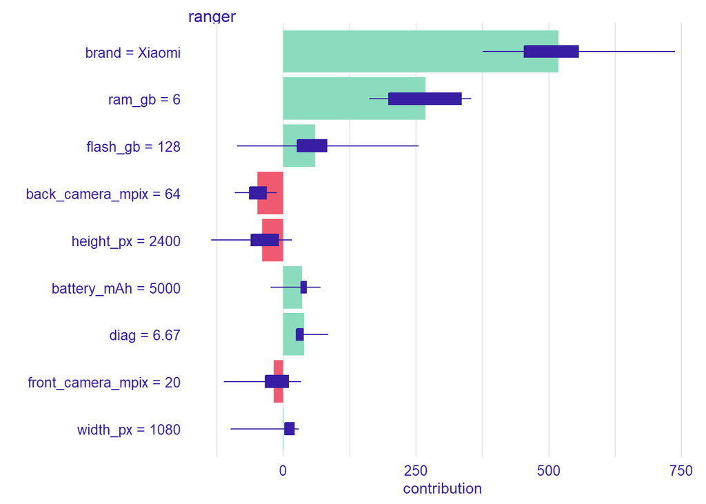

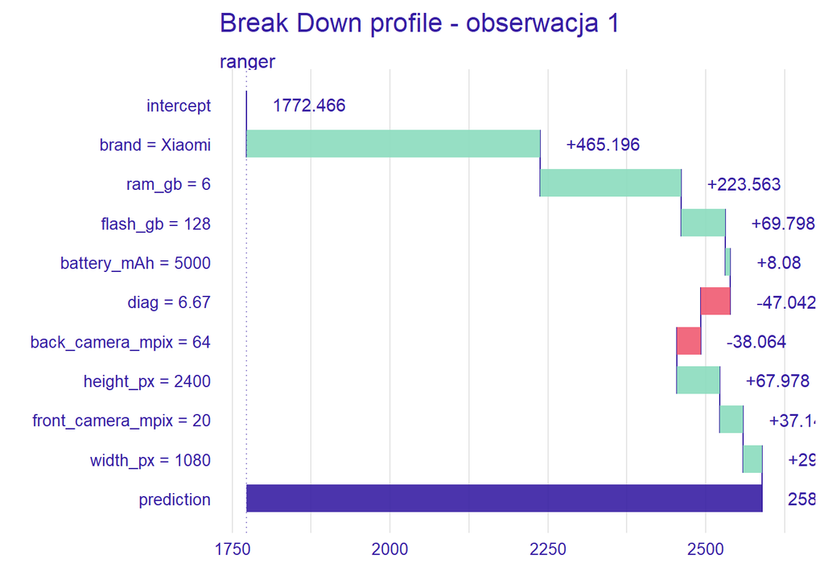

### Ważność zmiennych

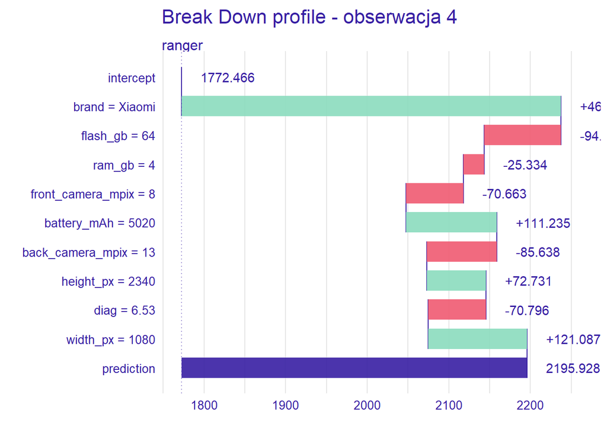

[figure not shown]

### Przeciwne wpływy

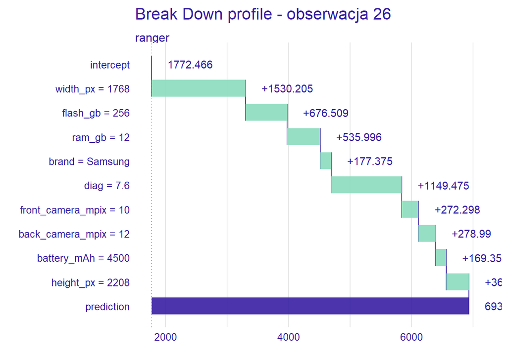

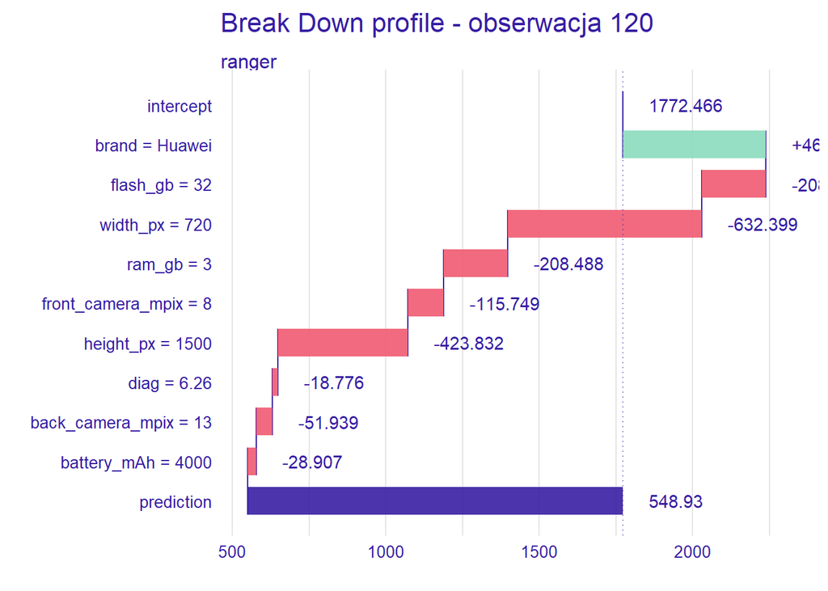

W przypadku tych dwóch obserwacji możemy zaobserwować diametralne różnice we wpływie zmiennych na wynik predykcji. Dla obserwacji 26 każda zmienna wpływa na wzrost ceny, co, patrząc na cenę tego telefonu (prawie 9000) jest w zasadzie zrozumiałe. Największy wpływ ma pamięć oraz wymiary telefonu, a marka właściwie minimalny - można zatem powiedzieć, że w tym wypadku cena faktycznie umotywowana jest parametrami, a nie marką producenta. W przypadku drugiej rozważanej obserwacji możemy zaobserwować negatywny wpływ większości zmiennych, a największy tych, które dla pierwszej obserwacji najbardziej “podwyższają” cenę. Zwróćmy jednak uwagę na wartości tych zmiennych - dla pierwszej obserwacji parametry są znacznie lepsze, nic więc dziwnego, że wpływają na cenę pozytywnie, natomiast dla drugiej zarówno pamięć jak i wymiary są dosyć słabe.

## Wnioski

Przeprowadzone analizy dotyczyły pojedynczych predykcji, i jak można zauważyć, ich wyniki znacznie różniły się między sobą. Rozważaliśmy telefony różnych marek, z różnych półek cenowych, więc jest to zrozumiałe. Na ich podstawie ciężko jest wyciągać wnioski dotyczące ogólnego działania naszego modelu i wyliczonej predykcji - do zauważenia ogólnych tendencji/wpływów należałoby użyć innych narzędzi, umożliwiających globalne wyjaśnienia. Możemy jednak zauważyć, że dla wszystkich 4 obserwacji wpływ marki na cenę był dodatni, a w 3 przypadkach bardzo znaczący - może to dać nam pewną intuicję do przyszłych analiz, że cena telefonu nie zależy jedynie od jego parametrów, a także od producenta.